# Análise preliminar: planos de saúde

Julio Trecenti

April 26, 2017

# Introdução

Nessa análise preliminar consideramos acórdãos do TJSP com assunto “Planos de saúde”. Esse filtro não é ideal para a análise pois existem processos envolvendo planos de saúde classificados em outros assuntos. No entanto, para um primeiro estudo esse escopo é suficiente.

A análise passa por três etapas, descritas abaixo.

- **Download**. Utilizamos os pacotes `esaj` e `tjsp` para baixar listas de processos automaticamente do TJSP.
- **Limpeza**. Seleção e transformação das variáveis.
- **Análise descritiva**. Alguns gráficos e tabelas sobre os casos baixados.

## Pacotes utilizados

Esse relatório foi construído em **RMarkdown** e é completamente reprodutível. Os pacotes utilizados para as análises estão listados abaixo:

```r
library(tidyverse)
library(stringr)
library(forcats)
library(lubridate)
library(esaj) # github.com/courtsbr/esaj
library(tjsp) # github.com/courtsbr/tjsp
```

# Download

Lista de assuntos do TJSP na Consulta de Julgados do Segundo Grau:

```r
# assuntos <- cjsg_tabs('assuntos')
# write_rds(assuntos, 'assuntos.rds', compress = 'bz')
assuntos <- read_rds('assuntos.rds')
```

Agora pegamos apenas o assunto de planos de saúde.

```r
cod_assuntos <- assuntos %>%
  filter(str_detect(titulo_leaf, 'Planos de S')) %>%
  with(cod_leaf)
```

Abrimos uma sessão de conexão com o TJSP e inserimos as informações de pesquisa (somente os assuntos).

```r
s <- cjsg_session()
parms <- cjsg_parms(s, assunto = cod_assuntos)
```

```r
npags <- cjsg_npags(s, parms = parms)
npags
```

```
## [1] 6053
```

A quantidade 6053 é muito grande! Vamos baixar apenas as primeiras mil páginas (os documentos estão ordenados por data de publicação do acórdão, das mais recentes para as mais antigas.) O download demorou aproximadamente 40 minutos.

```r
# nao rodar! demora
d_result <- cjsg(s, parms = parms, path = 'data-raw/cjsg', max_pag = 1000L)
```

Agora, vamos ler o conteúdo desses arquivos HTML. Para isso, utilizamos `cjsg_parse`:

```r
# nao rodar! demora
arqs <- dir('data-raw/cjsg', full.names = TRUE)
d_cjsg <- parse_cjsg(arqs)
write_rds(d_cjsg, 'd_cjsg.rds', compress = 'bz')
```

```r
d_cjsg <- read_rds('d_cjsg.rds')
d_cjsg
```

```
## # A tibble: 20,000 × 14
##                         arq    id cd_acordao                n_processo
##                       <chr> <chr>      <chr>                     <chr>
## 1  data-raw/cjsg/00001.html     1   10374368 1005055-52.2013.8.26.0100
## 2  data-raw/cjsg/00001.html     2   10374176 1037912-20.2014.8.26.0100
## 3  data-raw/cjsg/00001.html     3   10373830 1013212-09.2016.8.26.0003
## 4  data-raw/cjsg/00001.html     4   10373878 1114797-41.2015.8.26.0100
## 5  data-raw/cjsg/00001.html     5   10374080 1000401-63.2016.8.26.0505
## 6  data-raw/cjsg/00001.html     6   10373896 2003709-19.2017.8.26.0000
## 7  data-raw/cjsg/00001.html     7   10374070 1008741-23.2016.8.26.0011
## 8  data-raw/cjsg/00001.html     8   10373598 2011139-22.2017.8.26.0000
## 9  data-raw/cjsg/00001.html     9   10373673 2019983-58.2017.8.26.0000
## 10 data-raw/cjsg/00001.html    10   10373772 0000361-81.2010.8.26.0223
## # ... with 19,990 more rows, and 10 more variables: comarca <chr>,
## #   data_julgamento <chr>, data_registro <chr>, ementa <chr>,
## #   orgao_julgador <chr>, relatora <chr>, classe_assunto <chr>,
## #   txt_ementa <chr>, result <chr>, outros_numeros <chr>
```

Pronto! Temos uma base de dados com 20000. Essa base de dados tem as seguintes informações:

- `arq`: caminho do aquivo HTML.
- `id`: id do resultado.
- `cd_acordao`: código único do acórdão.
- `n_processo`: número do processo (um processo pode ter mais de um acórdão).
- `comarca`: comarca de origem do processo.
- `data_julgamento`: data de julgamento do processo.
- `data_registro`: data de registro da decisão (essa é a data usada para indexar as decisões.)
- `ementa`: ementa do processo.
- `orgao_julgador`: nome do órgão julgador.
- `relatora`: relator(a) do processo.
- `classe_assunto`: classe e assunto.
- `txt_ementa`: texto da ementa (geralmente igual à `ementa`.)
- `result`: indicador de leitura correta da página (geralmente tudo OK.)
- `outros_numeros`: outros números do processo.

# Limpeza

Vamos utilizar só uma parte dessas colunas. Para limpar os dados e obter a base `d_tidy`, rodamos o seguinte algoritmo.

```r
d_tidy <- d_cjsg %>%
  distinct(cd_acordao, .keep_all = TRUE) %>%
  select(cd_acordao, n_processo:classe_assunto) %>%
  separate(classe_assunto, c('classe', 'assunto'), sep = ' / ',
           extra = 'merge', fill = 'left') %>%
  mutate_at(vars(starts_with('data_')), dmy)
```

A base total contém 20.000 acórdãos de 17.289 processos.

# Análise descritiva

## Principais classes

```r
d_tidy %>%
  mutate(classe = fct_lump(classe, prop = 0.006,
                           other_level = 'Outros')) %>%
  count(classe, sort = TRUE) %>%
  mutate(prop = n/sum(n)) %>%
  janitor::add_totals_row() %>%
  mutate(prop = scales::percent(prop)) %>%
  knitr::kable()
```

| classe | n | prop |
| --- | --- | --- |
| Apelação | 9803 | 49.0% |
| Agravo de Instrumento | 5747 | 28.7% |
| Embargos de Declaração | 3824 | 19.1% |
| Agravo Regimental | 372 | 1.9% |
| Outros | 254 | 1.3% |
| Total | 20000 | 100.0% |

## Evolução no tempo

(tomar cuidado ao interpretar esse gráfico, pois não baixamos todos os casos!)

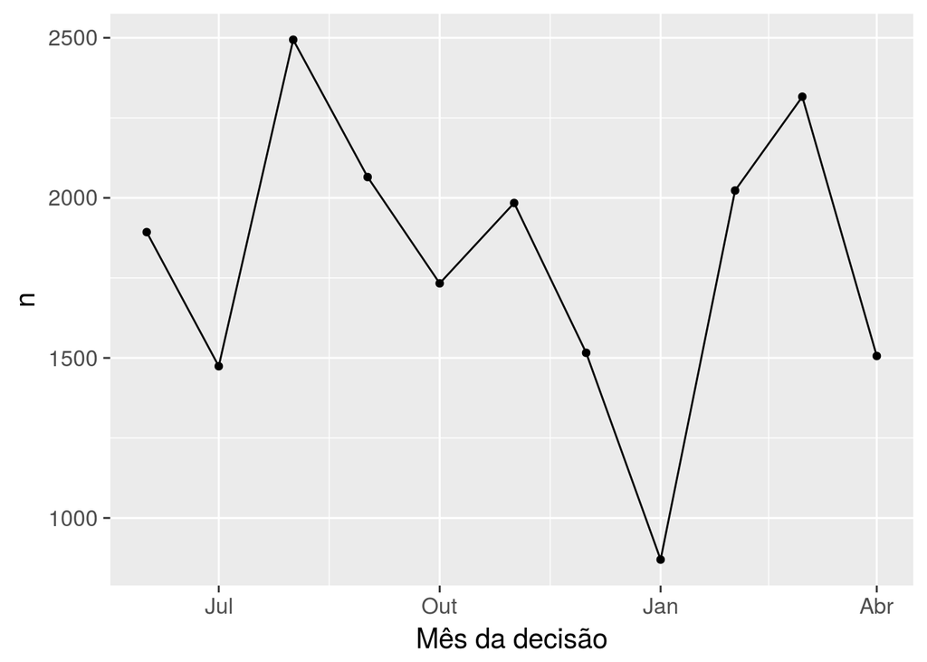

```r
d_tidy %>%
  mutate(classe = fct_lump(classe, prop = 0.1, other_level = 'Outros')) %>%
  mutate(mes_decisao = floor_date(data_julgamento, 'month')) %>%
  filter(mes_decisao > '2016-05-01') %>%
  count(mes_decisao) %>%
  ggplot(aes(x = mes_decisao, y = n)) +
  geom_line() +
  geom_point() +
  labs(x = 'Mês da decisão', 'Quantidade de decisões') +
  theme_gray(15)
```

## Comarcas

Nesse caso seria interessante dividir pela população.

```r
d_tidy %>%
  mutate(comarca = comarca %>%
           fct_infreq() %>%
           fct_lump(prop = 0.01, other_level = 'Outros')) %>%
  count(comarca) %>%
  mutate(prop = n / sum(n)) %>%
  janitor::add_totals_row() %>%
  mutate(prop = scales::percent(prop)) %>%
  knitr::kable()
```

| comarca | n | prop |
| --- | --- | --- |
| São Paulo | 11125 | 55.6% |
| São Bernardo do Campo | 850 | 4.2% |
| Santo André | 651 | 3.3% |
| Campinas | 518 | 2.6% |
| Santos | 466 | 2.3% |
| Osasco | 418 | 2.1% |
| São José dos Campos | 402 | 2.0% |
| Jundiaí | 330 | 1.6% |
| Ribeirão Preto | 323 | 1.6% |
| Guarulhos | 208 | 1.0% |
| São Caetano do Sul | 204 | 1.0% |
| Outros | 4505 | 22.5% |
| Total | 20000 | 100.0% |

## Relatores

No futuro, seremos capazes de analisar a taxa de decisões favoráveis / desfavoráveis por relator e câmara.

```r
d_tidy %>%
  mutate(relatora = relatora %>%
           fct_infreq() %>%
           fct_lump(prop = 0.02, other_level = 'Outros')) %>%
  count(relatora) %>%
  mutate(prop = n / sum(n)) %>%
  janitor::add_totals_row() %>%
  mutate(prop = scales::percent(prop)) %>%
  knitr::kable()
```

| relatora | n | prop |
| --- | --- | --- |
| J.L. Mônaco da Silva | 560 | 2.8% |
| Rômolo Russo | 524 | 2.6% |
| Rosangela Telles | 475 | 2.4% |
| José Aparício Coelho Prado Neto | 471 | 2.4% |
| Marcia Dalla Déa Barone | 469 | 2.3% |
| Moreira Viegas | 463 | 2.3% |
| Luis Mario Galbetti | 460 | 2.3% |
| José Carlos Ferreira Alves | 453 | 2.3% |
| Donegá Morandini | 450 | 2.2% |
| Carlos Alberto de Salles | 427 | 2.1% |
| José Joaquim dos Santos | 427 | 2.1% |
| Pedro de Alcântara da Silva Leme Filho | 419 | 2.1% |
| Outros | 14402 | 72.0% |
| Total | 20000 | 100.0% |

## Exemplos de textos

```r
set.seed(1)
d_tidy %>%
  sample_n(1) %>%
  with(ementa) %>%
  cat()
```

```
## Agravo de instrumento –  Tutela antecipada –  Realização de procedimentos restauradores, pós-cirurgia bariátrica –  Comprovada a urgência e a solicitação médica –  Evidência de risco à saúde da agravada - Prova inequívoca, convincente da verossimilhança das alegações da agravada -  Inteligência d…
##
##
##
##
##                                              Ementa: Agravo de instrumento –  Tutela antecipada –  Realização de procedimentos restauradores, pós-cirurgia bariátrica –  Comprovada a urgência e a solicitação médica –  Evidência de risco à saúde da agravada - Prova inequívoca, convincente da veross…
```

```r
set.seed(1)
d_tidy %>%
  sample_n(5) %>%
  with(ementa) %>%
  cat(sep = paste0('\n\n', strrep('-', 80), '\n\n'))
```

Agravo de instrumento – Tutela antecipada – Realização de procedimentos restauradores, pós-cirurgia bariátrica – Comprovada a urgência e a solicitação médica – Evidência de risco à saúde da agravada - Prova inequívoca, convincente da verossimilhança das alegações da agravada - Inteligência do artigo 300 do CPC – Inexistência de risco de irreversibilidade da medida - Decisão mantida -

```
                                            Ementa: Agravo de instrumento –  Tutela antecipada –  Realização de procedimentos restauradores, pós-cirurgia bariátrica –  Comprovada a urgência e a solicitação médica –  Evidência de risco à saúde da agravada - Prova inequívoca, convincente da verossimil…
```

```
                                            Ementa: Embargos de Declaração –  Operadora de plano de saúde Embargada condenada a oferecer plano individual ao Embargante –  Obscuridade inexistente –  Suposta obscuridade quanto ao plano a ser oferecido pela operadora constitui discordância do julgament…
```

```
                                            Ementa: PLANO DE SAÚDE –  Contrato coletivo empresarial –  Reajuste por aumento de sinistralidade e por faixa etária –  Reconhecida verossimilhança da suscitada abusividade da cláusula que prevê o primeiro deles –  Incidência excepcional do CDC ao caso - C…
```

```
                                            Ementa: Apelação - Plano de saúde - Funcionário aposentado - Contribuição por mais de dez anos - Exegese do artigo 31, "caput", da Lei nº 9.656/98 –  Direito de manutenção do beneficiário e sua dependente nas mesmas condições contratuais, respondendo pelo …
```

```
                                            Ementa: PLANO DE SAÚDE –  Cancelamento unilateral de plano de saúde familiar, pela operadora, fundado em inadimplemento –  Pedido de reativação- Parcial procedência –  Insurgência da ré –  Alegação de licitude da conduta, vez que emitiu correspondência inf…
```